# Geography 176A

### New Cases in NY, CA, LA, and FL

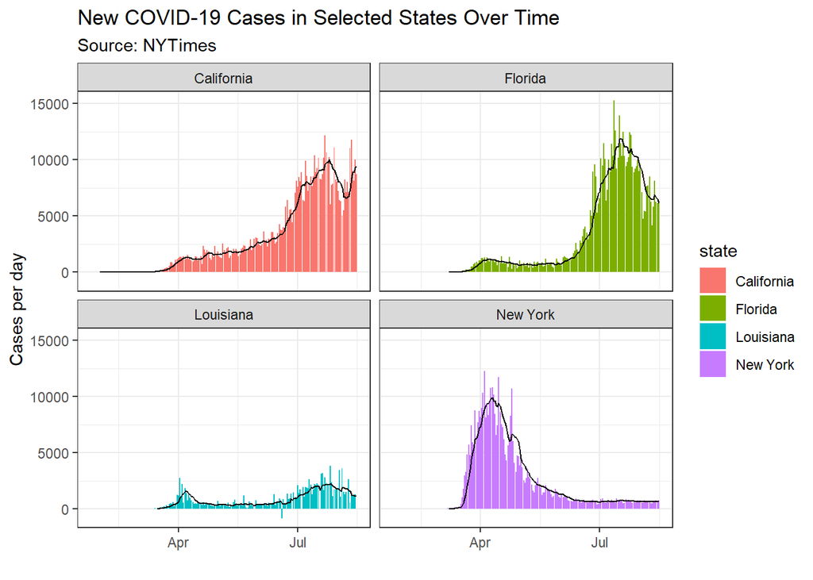

```r
stateList = c("New York", "California", "Louisiana", "Florida")

covid %>%
  group_by(date,state) %>%
  summarize(stateCases = sum(cases, na.rm = TRUE)) %>%
  filter(state %in% stateList) %>%
  ungroup() %>%
  group_by(state) %>%
  mutate(dailyCases = stateCases - lag(stateCases), rollingMean = rollmean(dailyCases,7,fill=NA,align="right")) %>%
  ungroup() ->
  dailyAndRolling

dailyAndRolling %>%
  ggplot(aes(x=date, fill=state)) +
  geom_bar(aes(y=dailyCases),stat="identity") +
  geom_line(aes(y=rollingMean)) +
  facet_wrap(~state) +
  labs(title = "New COVID-19 Cases in Selected States Over Time",
       x = "",
       y = "Cases per day",
       subtitle = "Source: NYTimes") +
  theme_bw()
```

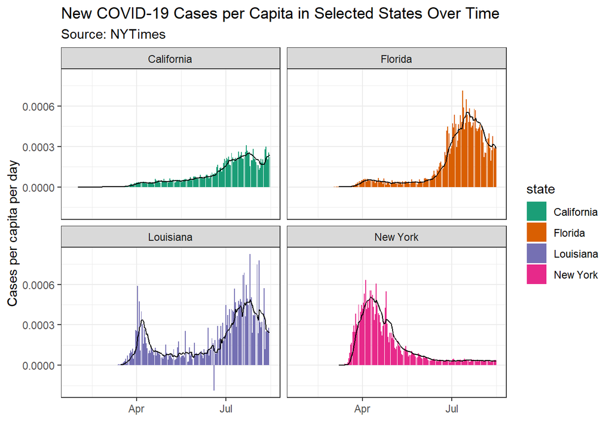

```r
# Get selected states pop est
PopulationEstimates %>%
  filter(Area_Name %in% c('New York', 'California', 'Louisiana', 'Florida')) %>%
  mutate(state = Area_Name) %>%
  select(state, POP_ESTIMATE_2019) ->
  totalPopEst

# Join pop ests to covid data
dailyAndRolling %>%
  group_by(state) %>%
  left_join(totalPopEst, by = "state") %>%
  mutate(casesPerCapita = dailyCases/as.numeric(POP_ESTIMATE_2019), rollingMeanPerCapita = rollmean(casesPerCapita,7,fill=NA,align="right")) %>%
  ungroup() ->
  statePerCapitaDailyAndRolling

# Plot
statePerCapitaDailyAndRolling %>%
  ggplot(aes(x=date, fill=state)) +
  geom_bar(aes(y=casesPerCapita),stat="identity") +
  geom_line(aes(y=rollingMeanPerCapita)) +
  scale_fill_brewer(palette="Dark2") +
  facet_wrap(~state) +
  labs(title = "New COVID-19 Cases per Capita in Selected States Over Time",
       x = "",
       y = "Cases per capita per day",
       subtitle = "Source: NYTimes") +
  theme_bw()
```

The primary indicator when analyzing the difference between cases per capita and pure cases is the population estimate.

```r
knitr::kable(
  totalPopEst %>%
    summarize(state, POP_ESTIMATE_2019),
  col.names = c("State", "Population Estimate"),
  caption = paste("Total Population Estimates per State (2019)")
)
```

Total Population Estimates per State (2019)

| State | Population Estimate |
| --- | --- |
| California | 39512223 |
| Florida | 21477737 |
| Louisiana | 4648794 |
| New York | 19453561 |

Based on new confirmed cases per capita versus purely new cases, California’s situation seems more in control with its population in comparison to Louisiana, which has a significantly worse situation when relating its population to number of confirmed cases. Both Florida and New York seem to have proportionately the expected number of cases in relation to their population.